# R Lab 7 — Sampling, Confidence Intervals & Sample Size

M731 Session 7 · Chapters 8 and 12 in R

Author

Shay Abbasi

# 1 How to use this lab

Work through the sections in order in a fresh `.qmd` file. Type the code rather than pasting it. Each section ends with **Try it** exercises; answers are at the end of the document.

**Dataset.** `data/maritime_survey.csv` — 800 Maritime Roast customers (instructor-simulated). For several exercises we treat these 800 people as a complete **population** so we can draw samples from it and compare the sample results with the “true” values. That is the only way to *see* sampling error.

| Variable | Meaning |
| --- | --- |
| `region` | Atlantic or Ontario_prospect |
| `tier` | Discovery, Standard, Signature |
| `age` | Age in years |
| `wtp` | Willingness to pay for a 340 g bag ($) |
| `satisfaction` | Satisfaction, 1–10 |
| `prefers_dark_roast` | Yes / No |

```r
library(tidyverse)
survey <- read_csv("data/maritime_survey.csv")
glimpse(survey[, 1:10])
```

```
Rows: 800
Columns: 10
$ respondent_id      <dbl> 1, 2, 3, 4, 5, 6, 7, 8, 9, 10, 11, 12, 13, 14, 15, …
$ region             <chr> "Atlantic", "Atlantic", "Atlantic", "Atlantic", "On…
$ subscriber_status  <chr> "Current", "Current", "Lapsed", "Lapsed", "Current"…
$ tier               <chr> "Discovery", "Standard", "Signature", "Signature", …
$ age                <dbl> 52, 34, 47, 40, 29, 21, 61, 40, 32, 43, 24, 26, 49,…
$ gender             <chr> "F", "M", "F", "M", "F", "M", "Nonbinary", "F", "M"…
$ tenure_months      <dbl> 4, 61, 14, 17, 7, 15, 4, 1, 13, 1, 5, 1, 6, 27, 6, …
$ wtp                <dbl> 28.03, 22.48, 21.01, 23.00, 19.51, 17.34, 23.00, 18…
$ satisfaction       <dbl> 5.3, 7.4, 5.2, 6.8, 4.2, 5.1, 6.0, 4.5, 6.4, 7.0, 5…
$ prefers_dark_roast <chr> "Yes", "Yes", "No", "No", "No", "No", "Yes", "No", …
```

# 2 The normal distribution and Z-scores

## 2.1 Z-scores

$Z = (X - \mu)/\sigma$ tells you how many standard deviations a value is from the mean.

```r
mu    <- mean(survey$wtp)
sigma <- sd(survey$wtp)
c(mean = mu, sd = sigma)
```

```
     mean        sd
21.637362  3.833888
```

```r
# A customer willing to pay $28: how unusual?
z <- (28 - mu) / sigma
z
```

```
[1] 1.659578
```

## 2.2 Areas under the curve

`pnorm(z)` gives the area to the **left** of z. `qnorm(p)` goes the other way: the z with area p to its left.

```r
pnorm(1) - pnorm(-1)   # within ±1 SD  -> 68.27%
```

```
[1] 0.6826895
```

```r
pnorm(2) - pnorm(-2)   # within ±2 SD  -> 95.45%
```

```
[1] 0.9544997
```

```r
pnorm(3) - pnorm(-3)   # within ±3 SD  -> 99.73%
```

```
[1] 0.9973002
```

```r
qnorm(0.975)           # Z for 95% two-sided  -> 1.96
```

```
[1] 1.959964
```

```r
qnorm(0.995)           # Z for 99% two-sided  -> 2.576
```

```
[1] 2.575829
```

```r
qnorm(0.95)            # Z for 90% two-sided  -> 1.645
```

```
[1] 1.644854
```

The textbook’s 68.26 / 95.44 / 99.74 are the same numbers rounded from printed tables.

## 2.3 Is WTP roughly normal?

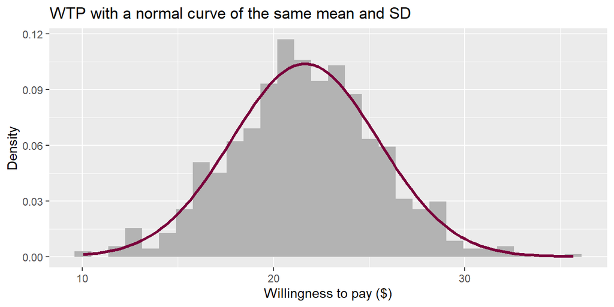

```r
ggplot(survey, aes(wtp)) +
  geom_histogram(aes(y = after_stat(density)), bins = 30, fill = "grey70") +
  stat_function(fun = dnorm, args = list(mean = mu, sd = sigma),
                colour = "#7A003C", linewidth = 1.2) +
  labs(x = "Willingness to pay ($)", y = "Density",
       title = "WTP with a normal curve of the same mean and SD")
```

```r
# Share of customers actually within ±1 SD
mean(abs(survey$wtp - mu) <= sigma)
```

```
[1] 0.68125
```

**Try it 2.1.** What percentage of customers would the normal curve predict to be willing to pay **more than $25**? What percentage actually are?

# 3 Population, sample, and sampling distributions

## 3.1 Draw one simple random sample

```r
set.seed(731)                       # makes the "random" draw repeatable
s1 <- slice_sample(survey, n = 50)  # simple random sample of 50
mean(s1$wtp)                        # sample mean  (X-bar)
```

```
[1] 20.907
```

```r
sd(s1$wtp)                          # sample SD    (S)
```

```
[1] 4.214958
```

```r
mean(survey$wtp)                    # population mean (mu)
```

```
[1] 21.63736
```

The gap between the sample mean and μ is **random sampling error**.

## 3.2 Many samples: the sampling distribution of the mean

```r
set.seed(731)
means_50 <- replicate(2000, mean(sample(survey$wtp, 50)))

c(mean_of_means = mean(means_50),
  sd_of_means   = sd(means_50),            # observed standard error
  formula_SE    = sigma / sqrt(50))        # sigma / sqrt(n)
```

```
mean_of_means   sd_of_means    formula_SE
   21.6588959     0.5295178     0.5421937
```

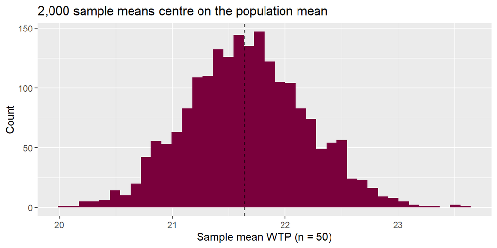

```r
ggplot(tibble(m = means_50), aes(m)) +
  geom_histogram(bins = 40, fill = "#7A003C") +
  geom_vline(xintercept = mu, linetype = 2) +
  labs(x = "Sample mean WTP (n = 50)", y = "Count",
       title = "2,000 sample means centre on the population mean")
```

The SD of the sample means matches $\sigma/\sqrt{n}$ — the **standard error of the mean**. (Sampling 50 of 800 is 6% of the population, so the real SE is slightly smaller than the formula; see the FPC section.)

## 3.3 The central limit theorem with a skewed variable

`tenure_months` is strongly right-skewed. The CLT says the **means** of samples from it will still look normal once n is large enough.

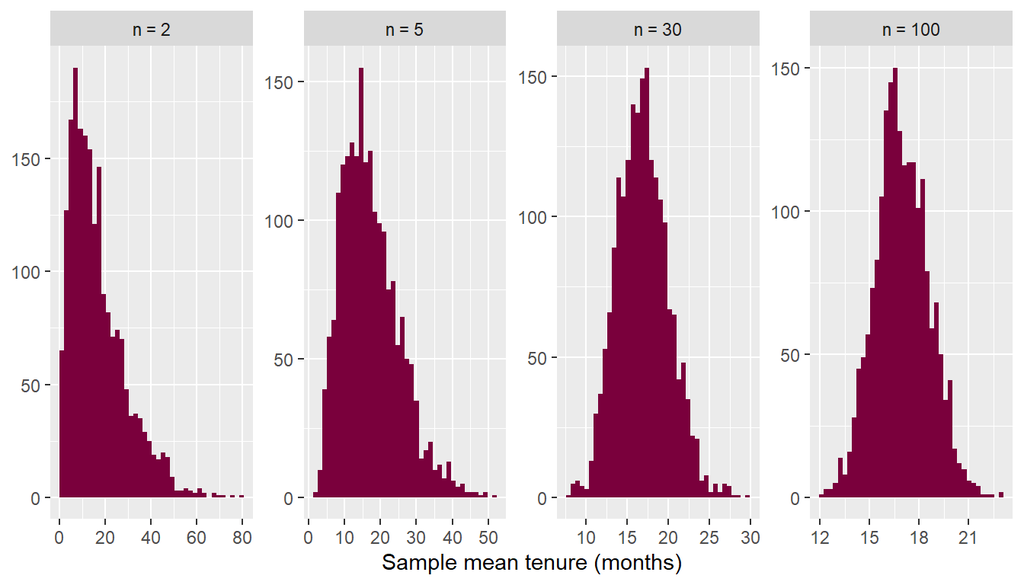

```r
set.seed(731)
clt <- map_dfr(c(2, 5, 30, 100), function(size) {
  tibble(n = paste("n =", size),
         mean = replicate(2000, mean(sample(survey$tenure_months, size))))
})
clt$n <- fct_inorder(clt$n)

ggplot(clt, aes(mean)) +
  geom_histogram(bins = 40, fill = "#7A003C") +
  facet_wrap(~ n, scales = "free", nrow = 1) +
  labs(x = "Sample mean tenure (months)", y = NULL)
```

**Try it 3.1.** Repeat the simulation for `wtp` with n = 10, 40 and 160. By what factor does the SD of the sample means shrink each time n is multiplied by 4?

# 4 Confidence intervals

## 4.1 CI for a mean

$\bar{X} \pm Z \cdot S/\sqrt{n}$

```r
ci_mean <- function(x, conf = 0.95) {
  x  <- x[!is.na(x)]
  z  <- qnorm(1 - (1 - conf) / 2)
  se <- sd(x) / sqrt(length(x))
  c(mean = mean(x), se = se, lower = mean(x) - z * se, upper = mean(x) + z * se)
}

ci_mean(s1$wtp)              # from our sample of 50
```

```
      mean         se      lower      upper
20.9070000  0.5960851 19.7386947 22.0753053
```

```r
ci_mean(s1$wtp, conf = 0.99) # wider at 99%
```

```
      mean         se      lower      upper
20.9070000  0.5960851 19.3715866 22.4424134
```

In practice, with small samples we use the *t* distribution (`t.test()` does this). For n ≥ 30 the two are almost identical:

```r
t.test(s1$wtp)$conf.int
```

```
[1] 19.70912 22.10488
attr(,"conf.level")
[1] 0.95
```

## 4.2 What “95% confident” means

Draw 100 samples, build 100 intervals, count how many contain μ.

```r
set.seed(42)
cis <- map_dfr(1:100, function(i) {
  x <- sample(survey$wtp, 50)
  as_tibble_row(ci_mean(x)) |> mutate(sample = i)
}) |> mutate(hit = lower <= mu & upper >= mu)

mean(cis$hit)   # close to 0.95
```

```
[1] 0.96
```

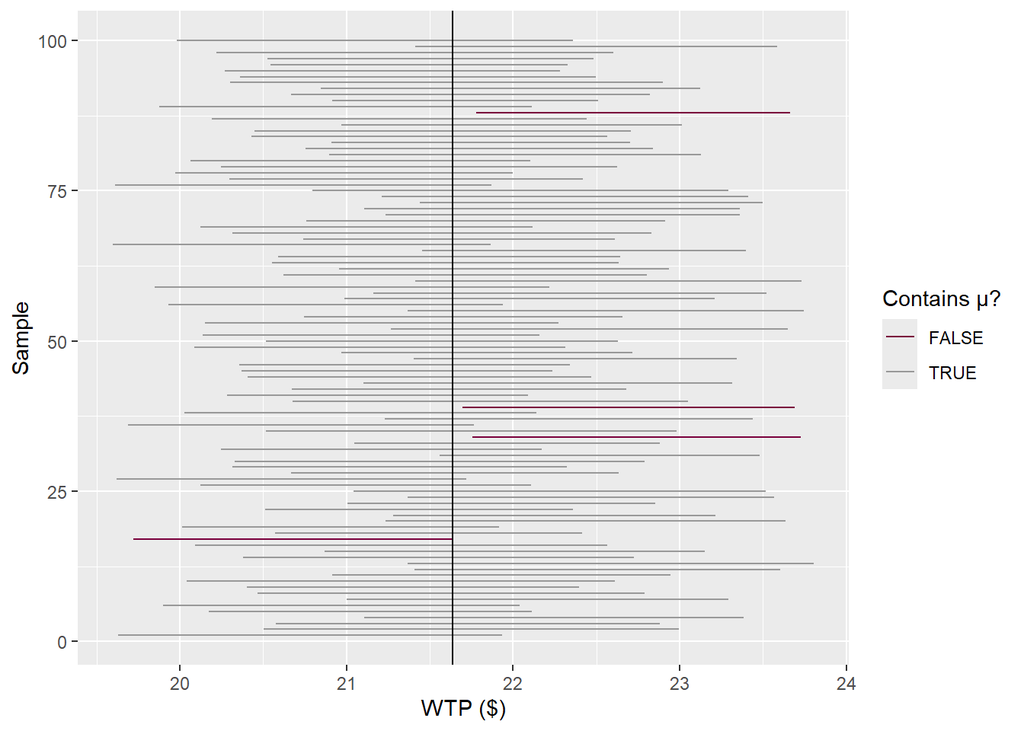

```r
ggplot(cis, aes(y = sample, xmin = lower, xmax = upper, colour = hit)) +
  geom_errorbarh(height = 0) +
  geom_vline(xintercept = mu) +
  scale_colour_manual(values = c(`TRUE` = "grey60", `FALSE` = "#7A003C")) +
  labs(x = "WTP ($)", y = "Sample", colour = "Contains μ?")
```

## 4.3 CI for a proportion

$P \pm Z\sqrt{P(1-P)/n}$

```r
ci_prop <- function(p, n, conf = 0.95) {
  z  <- qnorm(1 - (1 - conf) / 2)
  se <- sqrt(p * (1 - p) / n)
  c(p = p, se = se, lower = p - z * se, upper = p + z * se, moe = z * se)
}

p_dark <- mean(s1$prefers_dark_roast == "Yes")
ci_prop(p_dark, n = 50)
```

```
         p         se      lower      upper        moe
0.52000000 0.07065409 0.38152053 0.65847947 0.13847947
```

```r
# Check the RBC / Ipsos poll: n = 1,010, "±3.1%, 19 times out of 20"
ci_prop(0.5, 1010)["moe"]
```

```
       moe
0.03083596
```

`prop.test()` gives a slightly different (better) interval for small samples:

```r
prop.test(sum(s1$prefers_dark_roast == "Yes"), 50)$conf.int
```

```
[1] 0.3757565 0.6611910
attr(,"conf.level")
[1] 0.95
```

**Try it 4.1.** Gallup (2012) polled 3,117 adults: Obama 48%. Compute the 95% interval. Was the actual result (51%) inside it?

# 5 Sample size calculations

## 5.1 Write your own functions

```r
n_mean <- function(sigma, E, conf = 0.95) {
  z <- qnorm(1 - (1 - conf) / 2)
  ceiling(z^2 * sigma^2 / E^2)
}

n_prop <- function(E, P = 0.5, conf = 0.95) {
  z <- qnorm(1 - (1 - conf) / 2)
  ceiling(z^2 * P * (1 - P) / E^2)
}
```

## 5.2 Textbook examples

The text uses Z = 2 for “95.44%”. We can match that by passing the matching confidence level:

```r
conf_2sd <- pnorm(2) - pnorm(-2)   # 0.9545

n_mean(sigma = 1.39, E = 0.1, conf = conf_2sd)  # fast-food visits -> 773 (text: 772, rounding)
```

```
[1] 773
```

```r
n_prop(E = 0.04, P = 0.05, conf = conf_2sd)     # online buyers    -> 119
```

```
[1] 119
```

With the usual Z = 1.96:

```r
n_mean(sigma = 1.39, E = 0.1)
```

```
[1] 743
```

```r
n_prop(E = 0.04, P = 0.05)
```

```
[1] 115
```

```r
n_prop(E = 0.04)              # no idea about P -> worst case 0.5
```

```
[1] 601
```

## 5.3 How n responds to E, P and confidence

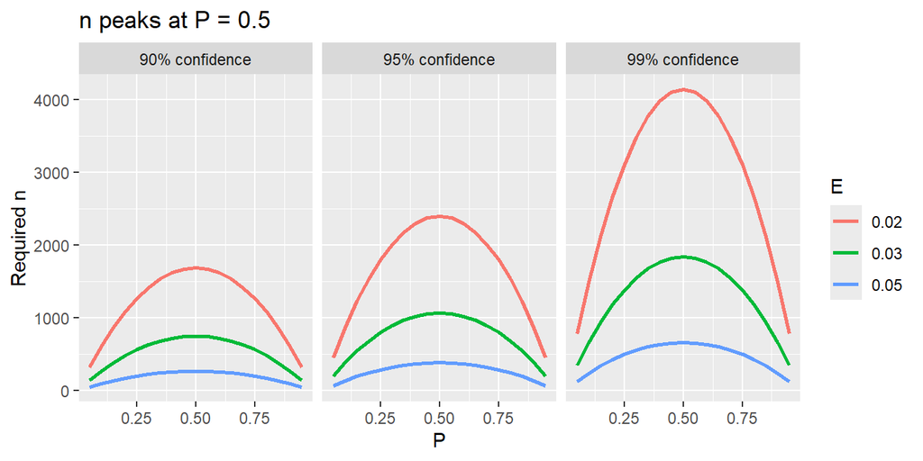

```r
grid <- expand_grid(E = c(0.02, 0.03, 0.05), P = seq(0.05, 0.95, 0.05),
                    conf = c(0.90, 0.95, 0.99)) |>
  mutate(n = pmap_dbl(list(E, P, conf), n_prop))

ggplot(grid, aes(P, n, colour = factor(E))) +
  geom_line(linewidth = 1) +
  facet_wrap(~ paste0(conf * 100, "% confidence")) +
  labs(colour = "E", y = "Required n", title = "n peaks at P = 0.5")
```

## 5.4 Use pilot data to estimate σ

Pretend the first 40 respondents are a pilot. How many people do we need to estimate mean WTP within ±$0.50 at 95%?

```r
pilot <- survey |> slice(1:40)
sigma_hat <- sd(pilot$wtp)
sigma_hat
```

```
[1] 3.775276
```

```r
n_mean(sigma = sigma_hat, E = 0.50)
```

```
[1] 220
```

## 5.5 Subgroups

You need ±5% at 95% for **each** tier separately:

```r
n_each <- n_prop(E = 0.05)
n_each
```

```
[1] 385
```

```r
survey |> count(tier) |> mutate(share = n / sum(n),
                                total_needed = ceiling(n_each / share))
```

```
# A tibble: 3 × 4
  tier          n share total_needed
  <chr>     <int> <dbl>        <dbl>
1 Discovery   147 0.184         2096
2 Signature   270 0.338         1141
3 Standard    383 0.479          805
```

The smallest group (Discovery, 18%) drives the total.

**Try it 5.1.** Curly fries: P = 0.80, 95% confidence, E = 0.06. **Try it 5.2.** Chili cook-off: σ = 3 oz, E = 4 oz, 99%.

# 6 Finite population correction

Use it when n is at least 5% of N.

```r
fpc_n <- function(n, N) ceiling(n * N / (N + n - 1))

fpc_n(400, 2000)   # textbook: 333
```

```
[1] 334
```

```r
fpc_n(400, 800)    # sampling half of our 800 customers
```

```
[1] 267
```

```r
fpc_n(385, 1e6)    # large population: no real change
```

```
[1] 385
```

# 7 How many people to contact

```r
units_needed <- function(completes, working = 1, incidence = 1, cooperation = 1) {
  ceiling(completes / (working * incidence * cooperation))
}
units_needed(400, working = 0.60, incidence = 0.43, cooperation = 0.35)  # ATM example
```

```
[1] 4430
```

# 8 Power and Type II error

`power.prop.test()` reproduces the textbook’s Exhibit 12.8 (sample size **per group**, α = 0.05):

```r
power_tab <- expand_grid(diff = c(0.01, 0.05, 0.10, 0.15),
                         power = c(0.5, 0.6, 0.7, 0.75, 0.8, 0.9)) |>
  mutate(n = map2_dbl(diff, power, \(d, pw)
           ceiling(power.prop.test(p1 = 0.5, p2 = 0.5 + d, power = pw)$n)))

power_tab |> pivot_wider(names_from = power, values_from = n,
                         names_prefix = "power_")
```

```
# A tibble: 4 × 7
   diff power_0.5 power_0.6 power_0.7 power_0.75 power_0.8 power_0.9
  <dbl>     <dbl>     <dbl>     <dbl>      <dbl>     <dbl>     <dbl>
1  0.01     19206     24492     30857      34698     39240     52530
2  0.05       767       978      1231       1384      1565      2095
3  0.1        191       243       305        343       388       519
4  0.15        84       107       134        150       170       227
```

For means use `power.t.test()`. Example: detect a $1 WTP difference between two groups with 80% power:

```r
power.t.test(delta = 1, sd = sigma, power = 0.80)$n
```

```
[1] 231.701
```

# 9 Drawing probability samples in R

```r
set.seed(2026)

# Simple random sample
srs <- slice_sample(survey, n = 80)

# Systematic sample: every k-th customer after a random start
k <- nrow(survey) / 80
start <- sample(1:k, 1)
sys <- survey |> slice(seq(start, n(), by = k))

# Proportionate stratified sample by tier (10% of each tier)
strat <- survey |> group_by(tier) |> slice_sample(prop = 0.10) |> ungroup()

# Compare to the population
bind_rows(Population = survey, SRS = srs, Systematic = sys, Stratified = strat,
          .id = "design") |>
  group_by(design) |>
  summarise(n = n(), mean_wtp = mean(wtp),
            pct_signature = mean(tier == "Signature"))
```

```
# A tibble: 4 × 4
  design         n mean_wtp pct_signature
  <chr>      <int>    <dbl>         <dbl>
1 Population   800     21.6         0.338
2 SRS           80     21.3         0.3
3 Stratified    79     21.1         0.342
4 Systematic    80     21.5         0.4
```

# 10 Seeing systematic error: non-response bias

Suppose unhappy customers are less likely to answer. A bigger sample does **not** fix this.

```r
set.seed(8)
# probability of responding rises with satisfaction
survey <- survey |> mutate(p_respond = plogis(-3 + 0.45 * satisfaction))

sim_nr <- map_dfr(c(50, 200, 800), function(size) {
  tibble(n = size, est = replicate(1000, {
    s <- slice_sample(survey, n = size, replace = TRUE)
    resp <- s[runif(size) < s$p_respond, ]
    mean(resp$satisfaction)
  }))
})

sim_nr |> group_by(n) |>
  summarise(mean_estimate = mean(est), spread = sd(est)) |>
  mutate(true_mean = mean(survey$satisfaction))
```

```
# A tibble: 3 × 4
      n mean_estimate spread true_mean
  <dbl>         <dbl>  <dbl>     <dbl>
1    50          6.15 0.243       5.84
2   200          6.15 0.117       5.84
3   800          6.15 0.0564      5.84
```

The spread (random error) shrinks as n grows; the gap between the estimate and the true mean (bias) does not.

# 11 Answers to Try it

```r
# 2.1
1 - pnorm(25, mu, sigma)          # normal model
```

```
[1] 0.1902208
```

```r
mean(survey$wtp > 25)             # actual
```

```
[1] 0.18375
```

```r
# 3.1  -> each 4x increase in n roughly halves the SE
sapply(c(10, 40, 160), \(n) sd(replicate(2000, mean(sample(survey$wtp, n)))))
```

```
[1] 1.2182294 0.5812284 0.2733095
```

```r
# 4.1
ci_prop(0.48, 3117)               # 46.2% to 49.8% -> 51% was outside
```

```
          p          se       lower       upper         moe
0.480000000 0.008948575 0.462461115 0.497538885 0.017538885
```

```r
# 5.1 curly fries
n_prop(E = 0.06, P = 0.80)        # 171 (if 6% is the standard error itself: 0.16/0.06^2 = 45)
```

```
[1] 171
```

```r
# 5.2 chili
n_mean(sigma = 3, E = 4, conf = 0.99)
```

```
[1] 4
```